# index

```python
# Instalamos la librería Fiona
!pip install fiona
```

[output not shown]

```python
# Importamos la función listlayers de Fiona
from  fiona import listlayers

# Definimos el enlace directo al archivo GeoPackage (.gpkg) alojado en GitHub
# Este archivo contiene datos geoespaciales relacionados con el mapa de la India
indiaMapsLink='https://github.com/in-Sinergy/IndiaData/raw/main/newindiaMaps_24378.gpkg'

# Usamos la función listlayers() para listar las capas disponibles en el archivo GeoPackage
listlayers(indiaMapsLink)
```

```
['country',
 'cities',
 'rivers',
 'centroid',
 'airports',
 'border',
 'states',
 'municipalities']
```

```python
# Importamos la librería GeoPandas para trabajar con datos geoespaciales
import geopandas as gpd

#Lee cada capa que contiene diferente información
states=gpd.read_file(indiaMapsLink,layer='states')
municipalities=gpd.read_file(indiaMapsLink,layer='municipalities')
airports=gpd.read_file(indiaMapsLink,layer='airports')
rivers = gpd.read_file(indiaMapsLink, layer ='rivers')
border=gpd.read_file(indiaMapsLink,layer='border')
```

```python
# Importamos la librería pandas para trabajar
import pandas as pd

# Enlace directo al archivo CSV que contiene información sobre puertos
# Este archivo está alojado en un repositorio de GitHub
portsFileLink = "https://github.com/CienciaDeDatosEspacial/GeoDataFrame_Analytics/raw/main/data/UpdatedPub150.csv"

# Usamos el método read_csv() de pandas para leer el archivo directamente desde la URL
# Esto nos permite cargar los datos del archivo CSV en un DataFrame de pandas
infoseaports = pd.read_csv(portsFileLink)

# La variable infoseaports ahora contiene los datos del archivo CSV en formato tabular
# Este formato facilita el análisis y manipulación de los datos
```

```python
# Organizando los datos cargados

# Renombrar columnas para que los nombres sean más manejables
# En este caso, cambiamos 'Main Port Name' a 'portName'
infoseaports.rename(columns={'Main Port Name': 'portName'}, inplace=True)

# Mantener solo las columnas que son relevantes para el análisis
# Aquí seleccionamos las columnas: 'portName', 'Country Code', 'Latitude' y 'Longitude'
infoseaports = infoseaports.loc[:, ['portName', 'Country Code', 'Latitude', 'Longitude']]

# Mostrar información sobre el DataFrame resultante para verificar los cambios
# Esto incluye el número de filas, columnas y tipos de datos
infoseaports.info()
```

```
<class 'pandas.core.frame.DataFrame'>
RangeIndex: 3739 entries, 0 to 3738
Data columns (total 4 columns):
 #   Column        Non-Null Count  Dtype
---  ------        --------------  -----
 0   portName      3739 non-null   object
 1   Country Code  3739 non-null   object
 2   Latitude      3739 non-null   float64
 3   Longitude     3739 non-null   float64
dtypes: float64(2), object(2)
memory usage: 117.0+ KB
```

```python
infoseaports.head()
```

|  | portName | Country Code | Latitude | Longitude |
| --- | --- | --- | --- | --- |
| 0 | Maurer | United States | 40.533333 | -74.250000 |
| 1 | Mangkasa Oil Terminal | Indonesia | -2.733333 | 121.066667 |
| 2 | Iharana | Madagascar | -13.350000 | 50.000000 |
| 3 | Andoany | Madagascar | -13.400000 | 48.300000 |
| 4 | Chake Chake | Tanzania | -5.250000 | 39.766667 |

```python
# Convertimos el DataFrame de pandas (infoseaports) en un GeoDataFrame de GeoPandas.
# Esto se hace agregando una columna de geometría que contiene puntos espaciales (longitude, latitude).
seaports = gpd.GeoDataFrame(
    data=infoseaports.copy(),  # Creamos una copia del DataFrame original
    geometry=gpd.points_from_xy(infoseaports.Longitude, infoseaports.Latitude),  # Convertimos a puntos espaciales
    crs=4326)  # Especificamos el CRS (Sistema de Referencia de Coordenadas) como WGS 84 (EPSG: 4326)

# CRS 4326 es un sistema de referencia geográfica basado en latitud y longitud (sin proyección).

# Filtramos los puertos que pertenecen únicamente a India
# Mantenemos solo las filas donde el código de país ('Country Code') es igual a 'India'
seaports_in = seaports[seaports['Country Code'] == 'India'].copy()

# Reiniciamos los índices del GeoDataFrame
# Esto asegura que el índice sea continuo después del filtrado
seaports_in.reset_index(drop=True, inplace=True)

# Reproyectamos los datos a un CRS proyectado (EPSG: 24378)
# Esto cambia el CRS de WGS 84 (4326) a un sistema proyectado adecuado para análisis en India
seaports_in_24378 = seaports_in.to_crs(24378)

# Ahora, `seaports_in_24378` contiene los datos reproyectados en un CRS que es más apropiado para medir distancias o áreas.
```

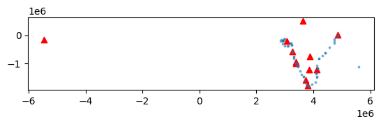

```python
# Filtramos los aeropuertos que son de tipo 'large_airport'
# No usamos "airports.type" porque "type" es una palabra reservada en Python
largeAirports = airports[airports['kind'] == 'large_airport']

# Reiniciamos los índices después del filtrado para mantener un índice limpio y continuo
largeAirports.reset_index(drop=True, inplace=True)

# Graficamos los aeropuertos grandes y los puertos marítimos

# Graficamos los aeropuertos grandes como triángulos rojos en el mapa
base = largeAirports.plot(color='red', marker="^")

# Sobre la base anterior (aeropuertos), graficamos los puertos marítimos de India
# Ajustamos la transparencia (alpha) y el tamaño de los marcadores (markersize)
seaports_in_24378.plot(ax=base, alpha=0.5, markersize=3)
```

```python
# No incluiremos el aeropuerto que está muy lejos, ya que parece ser un error

# Especificamos la lista de índices de los aeropuertos que queremos eliminar
# En este caso, eliminamos el aeropuerto con índice 9
notKeeping = [9]

# Eliminamos el aeropuerto del GeoDataFrame usando `drop()`
largeAirports.drop(index=notKeeping, inplace=True)

# Verificamos el resultado: mostramos el GeoDataFrame actualizado
largeAirports
```

|  | name | kind | latitude_deg | longitude_deg | elevation_ft | region_name | municipality | geometry |
| --- | --- | --- | --- | --- | --- | --- | --- | --- |
| 0 | Indira Gandhi International Airport | large_airport | 28.555630 | 77.095190 | 777.0 | Delhi (National Capital Territory) | New Delhi | POINT (3633095.495 515325.631) |
| 1 | Chhatrapati Shivaji International Airport | large_airport | 19.088699 | 72.867897 | 39.0 | Maharashtra | Mumbai | POINT (3268274.228 -570766.308) |
| 2 | Chennai International Airport | large_airport | 12.990005 | 80.169296 | 52.0 | Tamil Nadu | Chennai | POINT (4133330.538 -1204758.786) |
| 3 | Kempegowda International Airport | large_airport | 13.197900 | 77.706299 | 3000.0 | Karnataka | Bangalore | POINT (3850646.637 -1209475.503) |
| 4 | Netaji Subhash Chandra Bose International Airport | large_airport | 22.654699 | 88.446701 | 16.0 | West Bengal | Kolkata | POINT (4859299.409 23033.632) |
| 5 | Dabolim Airport | large_airport | 15.380800 | 73.831398 | 150.0 | Goa | Vasco da Gama | POINT (3395287.625 -988979.096) |
| 6 | Rajiv Gandhi International Airport | large_airport | 17.231318 | 78.429855 | 2024.0 | Telangana | Hyderabad | POINT (3887479.897 -738327.8) |
| 7 | Cochin International Airport | large_airport | 10.152000 | 76.401901 | 30.0 | Kerala | Kochi | POINT (3730354.442 -1579292.478) |
| 8 | Thiruvananthapuram International Airport | large_airport | 8.482120 | 76.920097 | 15.0 | Kerala | Thiruvananthapuram | POINT (3807754.324 -1772954.52) |
| 10 | Manohar International Airport | large_airport | 15.744257 | 73.860625 | 552.0 | Goa | Mopa | POINT (3396252.235 -946987.828) |
| 11 | Rajkot International Airport | large_airport | 22.378824 | 71.039391 | 647.0 | Gujarat | Rajkot | POINT (3060527.463 -206910.991) |

```python
# Reiniciamos los índices del GeoDataFrame después de haber eliminado filas
# Esto es útil para asegurarnos de que los índices sean consecutivos y claros
# `drop=True` elimina los índices originales (no los convierte en una nueva columna)
# `inplace=True` aplica los cambios directamente en el GeoDataFrame sin crear una copia
largeAirports.reset_index(drop=True, inplace=True)
```

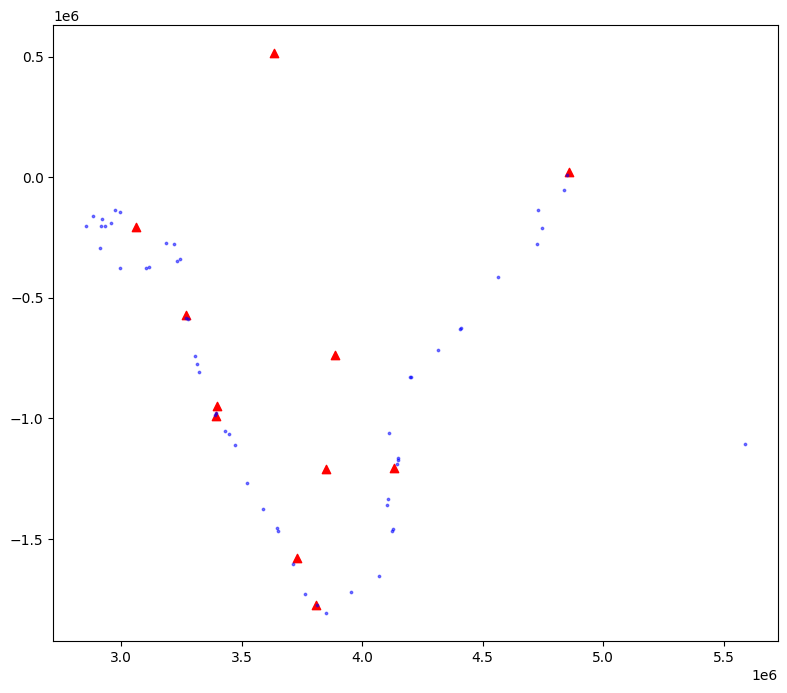

```python
# Graficamos los aeropuertos grandes en el mapa
# Usamos color rojo ('red') para los puntos y los marcamos con un triángulo ("^")
base = largeAirports.plot(
    color='red',        # Color de los puntos
    marker="^",         # Forma de los puntos (triángulos)
    figsize=(10, 8)     # Tamaño del gráfico (opcional)
)

# Sobre la base anterior, graficamos los puertos marítimos reproyectados
seaports_in_24378.plot(
    ax=base,            # Agregamos los puntos al mismo gráfico base (aeropuertos)
    alpha=0.5,          # Transparencia de los puntos
    markersize=3,       # Tamaño de los puntos
    color='blue'        # (Opcional) Color azul para los puertos marítimos
)
```

**Ejercicio 1**

Utilice dos mapas de puntos de su país.

Calcule la matriz de distancias para ambos mapas.

Seleccione una fila de la matriz de distancias y trace los dos puntos con la distancia mínima sobre el país que elija.

```python
# Trabajamos con puertos marítimos y aeropuertos grandes
# La matriz de distancia que estamos creando estará en kilómetros
# y los nombres estarán ordenados alfabéticamente para facilitar el acceso

distanceMatrixKM_sea_air = seaports_in_24378.set_index('portName').geometry.apply(
    # Usamos lambda para calcular la distancia desde cada puerto marítimo a todos los aeropuertos grandes
    lambda g: largeAirports.set_index('name').geometry.distance(g) / 1000  # Convertimos las distancias a kilómetros
).sort_index(axis=0).sort_index(axis=1)  # Ordenamos por nombres de puerto (filas) y aeropuertos (columnas)
```

```python
# Revisamos el contenido de la matriz de distancias calculada

# Los valores en las celdas son las distancias en kilómetros (calculadas previamente)
distanceMatrixKM_sea_air
```

| name portName | Chennai International Airport | Chhatrapati Shivaji International Airport | Cochin International Airport | Dabolim Airport | Indira Gandhi International Airport | Kempegowda International Airport | Manohar International Airport | Netaji Subhash Chandra Bose International Airport | Rajiv Gandhi International Airport | Rajkot International Airport | Thiruvananthapuram International Airport |
| --- | --- | --- | --- | --- | --- | --- | --- | --- | --- | --- | --- |
| Azhikal (Azhikkal) | 572.311418 | 867.675243 | 247.117458 | 433.561813 | 1893.370370 | 312.037782 | 471.166475 | 1891.674744 | 705.976888 | 1283.823547 | 452.551355 |
| Baleshwar | 1224.463315 | 1524.650569 | 1756.006567 | 1583.915964 | 1274.735168 | 1387.917553 | 1560.856873 | 204.709319 | 1035.661613 | 1670.385703 | 1879.296480 |
| Bedi | 1555.601039 | 494.080920 | 1592.453871 | 913.720692 | 975.733015 | 1357.940381 | 877.606711 | 1914.558316 | 1081.802612 | 105.943184 | 1799.516616 |
| Belekeri | 698.976710 | 525.812878 | 586.697471 | 92.578319 | 1590.787297 | 427.382245 | 128.813787 | 1781.427848 | 547.001890 | 941.475496 | 794.130740 |
| Beypore | 548.025813 | 972.611202 | 139.215488 | 540.276244 | 1980.320685 | 324.208743 | 577.182419 | 1916.767594 | 764.103919 | 1389.683135 | 345.635054 |
| Bhavnagar | 1328.562945 | 309.980039 | 1415.940738 | 746.959450 | 903.975849 | 1148.597754 | 706.999715 | 1697.176502 | 841.126508 | 142.729391 | 1624.481741 |
| Calcutta | 1409.734998 | 1684.659934 | 1943.436621 | 1764.220352 | 1317.880459 | 1576.034034 | 1739.999164 | 16.659074 | 1218.688610 | 1802.418167 | 2064.561279 |
| Calicut (Kozhikode) | 547.646602 | 962.054817 | 149.660932 | 529.719585 | 1970.765596 | 319.674544 | 566.615717 | 1912.294076 | 756.507377 | 1379.116650 | 356.199699 |
| Chennai (Madras) | 19.709157 | 1074.931433 | 569.805508 | 777.929927 | 1781.276498 | 296.691871 | 788.921051 | 1407.102101 | 521.035194 | 1465.213791 | 674.084269 |
| Cuddalore | 156.224295 | 1148.220828 | 434.121749 | 799.082526 | 1931.785622 | 293.740977 | 818.497239 | 1574.274557 | 656.581632 | 1553.770386 | 509.666240 |
| Dahej | 1301.693722 | 297.171815 | 1398.288958 | 732.739533 | 894.229283 | 1125.402539 | 692.290756 | 1666.962502 | 811.322411 | 174.133999 | 1606.841598 |
| Dhamra | 1168.481763 | 1519.852506 | 1704.860395 | 1558.453803 | 1326.395534 | 1341.697514 | 1537.015781 | 258.739263 | 1007.327649 | 1683.866075 | 1823.156681 |
| Gangavaram | 637.151426 | 1139.953672 | 1166.220544 | 1073.507474 | 1381.501777 | 803.674676 | 1059.254364 | 793.907417 | 530.581396 | 1410.892966 | 1291.061625 |
| Gopalpur | 900.089463 | 1303.649497 | 1432.246469 | 1301.274525 | 1313.916091 | 1067.774712 | 1282.380450 | 527.945785 | 749.015087 | 1516.023207 | 1554.848963 |
| Haldia Port | 1347.676978 | 1650.125561 | 1883.211643 | 1716.869455 | 1330.642053 | 1517.904175 | 1693.560108 | 81.080883 | 1168.965599 | 1781.561799 | 2002.370621 |
| Hazira | 1243.714613 | 226.973837 | 1329.247689 | 662.592477 | 950.106826 | 1061.105155 | 622.214112 | 1667.573656 | 762.632453 | 222.043133 | 1537.803106 |
| Honavar | 667.798759 | 578.005138 | 534.229623 | 144.717433 | 1634.934493 | 391.025670 | 181.279157 | 1792.198913 | 558.529077 | 993.942164 | 741.625239 |
| Jafarabad | 1323.253107 | 256.272017 | 1357.639268 | 679.688835 | 1037.567568 | 1120.522070 | 642.510699 | 1802.185676 | 865.218385 | 173.969575 | 1565.271933 |
| Jaigarh Bay | 924.759771 | 207.236341 | 907.077597 | 230.626843 | 1326.304227 | 690.653128 | 192.154829 | 1736.413684 | 572.670123 | 620.514914 | 1114.878789 |
| Jawaharlal Nehru Port (Nhava Shiva) | 1055.742582 | 18.070413 | 1091.426205 | 419.656689 | 1157.284717 | 846.582872 | 379.824525 | 1694.696533 | 628.346867 | 437.042713 | 1299.786813 |
| Kakinada Bay | 522.350960 | 1056.867453 | 1043.507596 | 959.852448 | 1406.869366 | 678.415182 | 947.789834 | 916.979802 | 428.388796 | 1353.721809 | 1173.279216 |
| Kamarajar Port | 37.341569 | 1066.142533 | 585.018897 | 775.750512 | 1763.622726 | 301.188080 | 785.740454 | 1389.174196 | 505.792399 | 1454.346633 | 692.102341 |
| Kandla | 1577.702893 | 525.801851 | 1630.211870 | 952.074091 | 926.986545 | 1386.801175 | 915.071949 | 1892.842623 | 1095.131050 | 112.794187 | 1837.790718 |
| Karaikal Port | 255.730382 | 1236.505690 | 414.115225 | 870.464893 | 2036.545766 | 373.312011 | 893.114622 | 1654.332274 | 760.785066 | 1645.816357 | 446.795034 |
| Karwar | 718.812417 | 508.180178 | 606.200213 | 72.578373 | 1580.540086 | 448.245901 | 110.791697 | 1787.887696 | 554.083220 | 922.889578 | 813.312441 |
| Kattupalli Port | 42.471691 | 1063.515501 | 589.149715 | 774.976541 | 1758.601358 | 302.408872 | 784.686687 | 1384.282658 | 501.434118 | 1451.137919 | 697.045693 |
| Kochi (Cochin) | 579.398917 | 1123.481638 | 29.637193 | 690.830596 | 2119.591085 | 416.936737 | 727.975667 | 1989.704975 | 882.031660 | 1540.537625 | 195.119209 |
| Kolachel | 665.750233 | 1366.720571 | 257.688528 | 936.370711 | 2332.817434 | 597.881412 | 972.833951 | 2090.067696 | 1069.674920 | 1784.709472 | 54.724320 |
| Krishnapatnam | 146.653927 | 975.609775 | 645.143945 | 720.773158 | 1646.281172 | 301.804728 | 725.136807 | 1315.148653 | 392.273590 | 1354.210919 | 775.779330 |
| Machilipatnam | 382.237857 | 966.484447 | 885.609158 | 820.394906 | 1458.289489 | 516.885208 | 812.261944 | 1076.931617 | 325.036409 | 1297.739772 | 1022.735945 |
| Machilipatnam | 382.785719 | 968.194349 | 886.777158 | 822.240764 | 1458.794459 | 518.295338 | 814.112315 | 1075.627487 | 326.739073 | 1299.243632 | 1023.651731 |
| Magdalla | 1240.667403 | 233.439585 | 1332.301024 | 667.600922 | 937.786477 | 1060.769285 | 626.987622 | 1654.100871 | 756.589272 | 226.730464 | 1540.852263 |
| Mandvi | 1629.268209 | 563.155179 | 1653.124781 | 974.614362 | 1008.625803 | 1427.480463 | 939.663117 | 1984.204805 | 1158.852377 | 183.242219 | 1859.384372 |
| Marmagao | 774.191041 | 432.005653 | 684.382718 | 5.872304 | 1519.709865 | 511.549581 | 38.350292 | 1781.013886 | 554.378731 | 845.334884 | 891.404489 |
| Mumbai (Bombay) | 1063.974143 | 13.854353 | 1096.561314 | 423.696588 | 1158.702895 | 853.833084 | 384.144851 | 1702.646411 | 637.515492 | 431.305332 | 1304.859713 |
| Mundra | 1593.548068 | 529.849663 | 1624.594702 | 945.833698 | 989.020123 | 1394.108761 | 910.256761 | 1948.194674 | 1120.993990 | 144.349759 | 1831.304001 |
| Nagappattinam | 263.805130 | 1241.576356 | 410.854377 | 873.963018 | 2044.099804 | 377.995936 | 896.902466 | 1662.022316 | 768.099172 | 1651.270361 | 440.434091 |
| Navlakhi | 1554.493313 | 505.781073 | 1611.920514 | 934.282837 | 915.764609 | 1365.318791 | 896.899982 | 1869.487858 | 1070.533727 | 89.416451 | 1819.697001 |
| New Mangalore | 612.987113 | 742.305145 | 373.885042 | 306.908155 | 1786.466163 | 332.211456 | 345.143159 | 1857.503178 | 642.444990 | 1157.529411 | 579.610518 |
| Okha | 1624.756428 | 554.027452 | 1632.451358 | 955.071711 | 1056.898386 | 1416.679889 | 921.291199 | 2015.933536 | 1163.260941 | 204.781376 | 1837.844922 |
| Pamban | 451.300432 | 1346.325001 | 348.120970 | 946.369202 | 2210.814220 | 494.033116 | 975.568416 | 1851.059059 | 931.613134 | 1763.016338 | 289.694936 |
| Panaji | 775.162837 | 423.339272 | 691.830399 | 13.839855 | 1509.902417 | 514.153969 | 28.558481 | 1774.010833 | 548.447845 | 837.234826 | 899.047414 |
| Paradip | 1102.207602 | 1487.023756 | 1640.481658 | 1509.724304 | 1348.555184 | 1280.012166 | 1489.470357 | 326.837600 | 957.584090 | 1666.505509 | 1756.617553 |
| Pipavav Bandar | 1316.270646 | 252.270142 | 1356.670668 | 679.335598 | 1025.232743 | 1115.831237 | 641.717456 | 1787.242657 | 855.186242 | 172.014248 | 1564.496420 |
| Pondicherry | 129.619976 | 1134.038977 | 452.068819 | 791.713880 | 1907.633457 | 285.784038 | 809.944178 | 1549.015797 | 633.626263 | 1537.796879 | 533.894713 |
| Porbandar | 1523.933030 | 451.546440 | 1523.995220 | 846.804861 | 1084.261755 | 1311.534583 | 813.269237 | 1973.407883 | 1072.361876 | 172.574540 | 1729.349995 |
| Port Blair | 1456.483549 | 2379.117333 | 1915.535554 | 2194.273279 | 2538.435158 | 1738.895186 | 2195.947066 | 1342.766759 | 1738.256164 | 2681.098371 | 1899.695336 |
| Port Dabhol | 946.314329 | 174.409781 | 938.858310 | 263.195194 | 1296.938671 | 716.691989 | 224.337207 | 1728.283628 | 578.707057 | 588.427369 | 1146.791584 |
| Quilon (Kollam) | 641.850945 | 1260.467629 | 154.093511 | 827.377170 | 2248.813278 | 527.374308 | 864.761000 | 2066.823559 | 999.014271 | 1677.389075 | 61.569676 |
| Ratnagiri | 900.382879 | 244.190625 | 871.094849 | 193.899992 | 1359.017196 | 661.302396 | 155.957057 | 1745.101101 | 566.879244 | 656.940499 | 1078.743590 |
| Sikka | 1561.836233 | 496.138729 | 1589.243602 | 910.505567 | 1002.479305 | 1360.491956 | 875.054973 | 1938.086436 | 1092.701565 | 126.051497 | 1795.883703 |
| Trivandrum | 652.720434 | 1318.737493 | 209.489271 | 887.124391 | 2294.766104 | 564.407889 | 923.988227 | 2079.008402 | 1036.984408 | 1736.307771 | 3.575854 |
| Tuticorin | 547.670815 | 1338.951093 | 263.852977 | 920.513073 | 2259.714865 | 522.253229 | 953.713696 | 1966.328651 | 985.523295 | 1757.888112 | 153.525538 |
| Vadinar Terminal | 1577.468614 | 510.544458 | 1601.029323 | 922.413080 | 1012.270701 | 1374.838193 | 887.293710 | 1955.020135 | 1109.624845 | 143.616159 | 1807.439574 |
| Veraval | 1409.429185 | 336.943968 | 1411.527923 | 733.442189 | 1096.004227 | 1195.870894 | 699.225942 | 1907.309566 | 964.510166 | 180.828045 | 1617.505807 |
| Vishakhapatnam | 644.934800 | 1144.237836 | 1174.126726 | 1080.006229 | 1378.771029 | 811.500882 | 1065.582518 | 786.002052 | 536.432356 | 1413.378002 | 1298.892429 |

```python
# Seleccionamos uno de los puertos marítimos, en este caso, "Panaji"
# Queremos encontrar los aeropuertos más cercanos a este puerto

# Usamos `.loc['Panaji', :]` para extraer la fila correspondiente al puerto "Panaji"
# Esto nos da las distancias de "Panaji" a todos los aeropuertos grandes

# Usamos `.sort_values(ascending=True)` para ordenar las distancias de menor a mayor
# Esto nos permite identificar rápidamente los aeropuertos más cercanos
distanceMatrixKM_sea_air.loc['Panaji', :].sort_values(ascending=True)
```

| name | Panaji |
| --- | --- |
| Dabolim Airport | 13.839855 |
| Manohar International Airport | 28.558481 |
| Chhatrapati Shivaji International Airport | 423.339272 |
| Kempegowda International Airport | 514.153969 |
| Rajiv Gandhi International Airport | 548.447845 |
| Cochin International Airport | 691.830399 |
| Chennai International Airport | 775.162837 |
| Rajkot International Airport | 837.234826 |
| Thiruvananthapuram International Airport | 899.047414 |
| Indira Gandhi International Airport | 1509.902417 |
| Netaji Subhash Chandra Bose International Airport | 1774.010833 |

**dtype:** float64

```python
# Seleccionamos los dos aeropuertos más cercanos
# Usamos sus índices en el DataFrame `airports`, en este caso (5, 172)
Closest_Air = airports.loc[(5, 172), :]

# Mostramos los datos de los dos aeropuertos seleccionados
Closest_Air
```

|  | name | kind | latitude_deg | longitude_deg | elevation_ft | region_name | municipality | geometry |
| --- | --- | --- | --- | --- | --- | --- | --- | --- |
| 5 | Dabolim Airport | large_airport | 15.380800 | 73.831398 | 150.0 | Goa | Vasco da Gama | POINT (3395287.625 -988979.096) |
| 172 | Manohar International Airport | large_airport | 15.744257 | 73.860625 | 552.0 | Goa | Mopa | POINT (3396252.235 -946987.828) |

```python
# Instalamos la librería mapclassify
# Esta librería se utiliza para clasificar datos continuos en intervalos o categorías
# Es especialmente útil en la creación de mapas temáticos con GeoPandas
!pip install mapclassify
```

```
Downloading mapclassify-2.8.1-py3-none-any.whl (59 kB)
   ━━━━━━━━━━━━━━━━━━━━━━━━━━━━━━━━━━━━━━━━ 59.1/59.1 kB 2.3 MB/s eta 0:00:00
```

```python
# Graficamos los dos aeropuertos más cercanos en el mapa
# Usamos la función explore() para crear un mapa interactivo
# Los puntos de los aeropuertos se muestran en color rojo con un radio de 10
base = Closest_Air.explore(
    color='red',                     # Color de los puntos de los aeropuertos
    marker_kwds=dict(radius=10)      # Configuración de los marcadores: radio de 10
)

# Sobre el mismo mapa (base), graficamos el puerto marítimo de Panaji
seaports_in_24378[
    seaports_in_24378.portName.str.contains('Panaji')  # Filtramos el puerto con nombre "Panaji"
].explore(
    m=base,                          # Agregamos el puerto marítimo al mapa existente
    marker_kwds=dict(radius=10)      # Configuración del marcador del puerto: radio de 10
)
```

Make this Notebook Trusted to load map: File -> Trust Notebook

[interactive chart not shown]

**Ejercicio 2**

Utilice un mapa de puntos y un mapa de líneas de su país.

Calcule la matriz de distancias para ambos.

Seleccione una línea de la matriz de distancias y trace el punto más cercano y el más lejano a esa línea.

```python
# Revisamos qué información tenemos sobre los ríos
# El DataFrame 'rivers' contiene datos geoespaciales sobre los ríos disponibles
# Esto incluye nombres, geometrías y posiblemente otros atributos de los ríos
rivers
```

|  | NAME | SYSTEM | geometry |
| --- | --- | --- | --- |
| 0 | Ganges | None | LINESTRING (3890449.339 797278.081, 3885180.07... |
| 1 | Brahmaputra | None | LINESTRING (5359670.918 873592.559, 5346146.45... |
| 2 | Indus | None | MULTILINESTRING ((2768998.497 -54259.315, 2767... |

```python
# Seleccionamos las filas del GeoDataFrame 'rivers' relacionadas con el río Ganges
# Usamos la columna 'NAME' para buscar ríos cuyo nombre contenga la palabra 'Ganges'
Ganges = rivers[rivers.NAME.str.contains('Ganges')]

# El resultado es un subconjunto del GeoDataFrame 'rivers' que incluye
# únicamente las geometrías y datos relacionados con el río Ganges
```

```python
# Creamos una matriz de distancias entre los aeropuertos grandes y las secciones del río Ganges
# La matriz contendrá las distancias en kilómetros

distanceMatrixKM_Ganges_air = Ganges.set_index('NAME').geometry.apply(
    # Para cada geometría del río Ganges, calculamos la distancia a los aeropuertos
    lambda g: largeAirports.set_index('name').geometry.distance(g) / 1000  # Convertimos de metros a kilómetros
).sort_index(axis=0).sort_index(axis=1)  # Ordenamos los índices y columnas alfabéticamente

# Mostramos la matriz de distancias
distanceMatrixKM_Ganges_air
```

| name NAME | Chennai International Airport | Chhatrapati Shivaji International Airport | Cochin International Airport | Dabolim Airport | Indira Gandhi International Airport | Kempegowda International Airport | Manohar International Airport | Netaji Subhash Chandra Bose International Airport | Rajiv Gandhi International Airport | Rajkot International Airport | Thiruvananthapuram International Airport |
| --- | --- | --- | --- | --- | --- | --- | --- | --- | --- | --- | --- |
| Ganges | 1415.001311 | 1153.041373 | 1848.548739 | 1431.653342 | 126.566956 | 1460.48128 | 1393.720243 | 256.402906 | 997.147547 | 1008.302465 | 2020.025785 |

```python
# Verificamos el orden de las distancias desde el primer segmento del río Ganges hacia los aeropuertos
# Seleccionamos la primera fila de la matriz de distancias (correspondiente al primer segmento del río Ganges)
# y ordenamos las distancias en orden ascendente para identificar los aeropuertos más cercanos

distanceMatrixKM_Ganges_air.iloc[0, :].sort_values(axis=0, ascending=True)
```

| name | Ganges |
| --- | --- |
| Indira Gandhi International Airport | 126.566956 |
| Netaji Subhash Chandra Bose International Airport | 256.402906 |
| Rajiv Gandhi International Airport | 997.147547 |
| Rajkot International Airport | 1008.302465 |
| Chhatrapati Shivaji International Airport | 1153.041373 |
| Manohar International Airport | 1393.720243 |
| Chennai International Airport | 1415.001311 |
| Dabolim Airport | 1431.653342 |
| Kempegowda International Airport | 1460.481280 |
| Cochin International Airport | 1848.548739 |
| Thiruvananthapuram International Airport | 2020.025785 |

**dtype:** float64

```python
# Identificamos el aeropuerto más cercano para cada segmento del río Ganges
# Utilizamos idxmin(axis=1) para encontrar el índice (nombre del aeropuerto) con la menor distancia
# axis=1 indica que estamos operando fila por fila, es decir, para cada segmento del río
distanceMatrixKM_Ganges_air.idxmin(axis=1)
```

| NAME | 0 |
| --- | --- |
| Ganges | Indira Gandhi International Airport |

**dtype:** object

```python
# Identificamos el aeropuerto más lejano para cada segmento del río Ganges
# Utilizamos idxmax(axis=1) para encontrar el índice (nombre del aeropuerto) con la mayor distancia
# axis=1 indica que estamos operando fila por fila, es decir, para cada segmento del río
distanceMatrixKM_Ganges_air.idxmax(axis=1)
```

| NAME | 0 |
| --- | --- |
| Ganges | Thiruvananthapuram International Airport |

**dtype:** object

```python
# Filtramos los aeropuertos cuyo nombre contiene la palabra "Thiru"
# Usamos la columna 'name' del GeoDataFrame 'airports' y aplicamos el método str.contains()
# Esto selecciona solo las filas donde el nombre del aeropuerto incluye "Thiru"
airports[airports.name.str.contains('Thiru')]
```

|  | name | kind | latitude_deg | longitude_deg | elevation_ft | region_name | municipality | geometry |
| --- | --- | --- | --- | --- | --- | --- | --- | --- |
| 9 | Thiruvananthapuram International Airport | large_airport | 8.48212 | 76.920097 | 15.0 | Kerala | Thiruvananthapuram | POINT (3807754.324 -1772954.52) |

```python
# Seleccionamos dos aeropuertos específicos usando sus índices en el GeoDataFrame 'airports'
# En este caso, seleccionamos los aeropuertos con índices 0 y 9
# Usamos .loc para acceder a las filas por índice y seleccionamos todas las columnas (indicado por ':')
Clos_Far_Air = airports.loc[(0, 9), :]

# Ahora, los aeropuertos seleccionados se almacenan en el GeoDataFrame 'Clos_Far_Air'
# Este subconjunto puede usarse para graficar o realizar análisis adicionales
```

```python
Clos_Far_Air
```

|  | name | kind | latitude_deg | longitude_deg | elevation_ft | region_name | municipality | geometry |
| --- | --- | --- | --- | --- | --- | --- | --- | --- |
| 0 | Indira Gandhi International Airport | large_airport | 28.55563 | 77.095190 | 777.0 | Delhi (National Capital Territory) | New Delhi | POINT (3633095.495 515325.631) |
| 9 | Thiruvananthapuram International Airport | large_airport | 8.48212 | 76.920097 | 15.0 | Kerala | Thiruvananthapuram | POINT (3807754.324 -1772954.52) |

```python
# Primero, graficamos los aeropuertos seleccionados (primer y último en la lista)
# Usamos la función explore() para generar un mapa interactivo
# Los aeropuertos se muestran en color rojo y los marcadores tienen un radio de 10
base = Clos_Far_Air.explore(
    color='red',                    # Color de los marcadores para los aeropuertos
    marker_kwds=dict(radius=10)     # Configuración del tamaño del marcador
)

# Luego, agregamos al mismo mapa (base) el río Ganges
# Filtramos las filas de 'rivers' cuyo nombre contiene 'Ganges'
# Usamos explore() nuevamente para agregar esta capa al mapa interactivo existente
rivers[rivers.NAME.str.contains('Ganges')].explore(
    m=base                          # Agregamos la capa al mapa interactivo ya creado
)
```

Make this Notebook Trusted to load map: File -> Trust Notebook

[interactive chart not shown]

**Ejercicio 3**

Crear un CASCO para un conjunto de mapas de líneas.

Calcular la matriz de distancia entre los CASCO y un mapa de puntos.

Dibuje los CASCO y los puntos. Muestre los puntos más cercanos y más lejanos al CASCO.

```python
# Filtramos los ríos que tienen datos disponibles en la columna "SYSTEM"
# Usamos .isna() para identificar valores nulos (NaN) en la columna "SYSTEM"
# El operador ~ invierte la condición, seleccionando solo las filas donde "SYSTEM" no es nulo
rivers[~rivers.SYSTEM.isna()]
```

|  | NAME | SYSTEM | geometry |
| --- | --- | --- | --- |

```python
# Probamos con este conjunto de datos de ríos para India
# Usamos geopandas para leer el archivo shapefile (.shp) directamente desde la URL proporcionada
# El archivo contiene información geoespacial sobre los ríos de la India
indiaRivers = gpd.read_file("https://github.com/in-Sinergy/IndiaData/raw/main/Rivers/Rivers.shp")

# Visualizamos las primeras filas del GeoDataFrame para entender su estructura y contenido
indiaRivers.head()
```

|  | objectid | rivname | rilcode | origin | major_trib | bacode | ba_name | sub_basin | shape_Leng | geometry |
| --- | --- | --- | --- | --- | --- | --- | --- | --- | --- | --- |
| 0 | 155 | Ajay | 1 | Near Deoghar In The Santhal Parganas District ... | None | 2A | Ganga | Bhagirathi and others (Ganga Lower) | 308394.210815 | LINESTRING (4625672.355 4066335.487, 4625679.0... |
| 1 | 223 | Alaknanda | 1 | Garhwal Himalayas | None | 2A | Ganga | Above Ramganga Confluence | 206397.550749 | LINESTRING (3927501.39 4742662.37, 3927535.171... |
| 2 | 351 | Amba | 1 | None | None | 14 | West flowing rivers from Tapi to Tadri | Bhatsol and others | 103041.275292 | LINESTRING (3311469.037 3447641.467, 3311387.3... |
| 3 | 575 | Andi Odai | 1 | None | None | 05 | Cauvery | Cauvery Lower | 16491.503072 | LINESTRING (3889172.463 2576115.624, 3889182.8... |
| 4 | 578 | Andrangi Drain | 1 | None | None | 03 | Godavari | Godavari Lower | 13356.828787 | LINESTRING (4217069.63 3215665.789, 4217109.91... |

```python
# Seleccionamos únicamente las columnas que queremos conservar en el GeoDataFrame indiaRivers

keep = ['rivname', 'ba_name', 'sub_basin', 'geometry']

# Creamos un conjunto con las columnas que no queremos mantener
# Esto se hace restando las columnas a conservar del conjunto total de columnas
dontKeep = set(indiaRivers.columns.to_list()) - set(keep)

# Eliminamos las columnas no deseadas del GeoDataFrame
# Usamos drop() con el argumento columns=dontKeep para eliminar las columnas innecesarias
indiaRivers = indiaRivers.drop(columns=dontKeep)

# Mostramos el GeoDataFrame actualizado para verificar que solo contiene las columnas seleccionadas
indiaRivers
```

|  | rivname | ba_name | sub_basin | geometry |
| --- | --- | --- | --- | --- |
| 0 | Ajay | Ganga | Bhagirathi and others (Ganga Lower) | LINESTRING (4625672.355 4066335.487, 4625679.0... |
| 1 | Alaknanda | Ganga | Above Ramganga Confluence | LINESTRING (3927501.39 4742662.37, 3927535.171... |
| 2 | Amba | West flowing rivers from Tapi to Tadri | Bhatsol and others | LINESTRING (3311469.037 3447641.467, 3311387.3... |
| 3 | Andi Odai | Cauvery | Cauvery Lower | LINESTRING (3889172.463 2576115.624, 3889182.8... |
| 4 | Andrangi Drain | Godavari | Godavari Lower | LINESTRING (4217069.63 3215665.789, 4217109.91... |
| ... | ... | ... | ... | ... |
| 105 | Ghaghara | Ganga | None | MULTILINESTRING ((4460395.803 4198399.029, 446... |
| 106 | Karnaphuli | Minor rivers draining into Myanmar and Bangladesh | Khawthlangtuipui & Others | LINESTRING (5258047.759 3940507.574, 5258006.9... |
| 107 | Satluj | Indus (Up to border) | None | MULTILINESTRING ((3852813.193 4832742.626, 385... |
| 108 | Krishna | Krishna | None | MULTILINESTRING ((4088071.262 3097425.887, 408... |
| 109 | Musi | Krishna | Krishna Lower | LINESTRING (3783499.387 3266641.072, 3783537.5... |

110 rows × 4 columns

```python
# Reproyectamos el GeoDataFrame indiaRivers al sistema de referencia EPSG:24378
# EPSG:24378 es un sistema proyectado específico para la región de la India (metros como unidades)
indiaRivers_24378 = indiaRivers.to_crs(24378)

# Guardamos el GeoDataFrame reproyectado en una nueva variable 'indiaRivers_24378'
# Esto asegura que los datos estén listos para análisis espaciales precisos, como mediciones de distancia o área
```

```python
# Creamos sistemas agrupando los ríos según la columna 'ba_name' (nombre de la cuenca)
# El método dissolve combina todas las geometrías que comparten el mismo valor en la columna 'ba_name'
# Además, agrega (suma) cualquier dato numérico en las otras columnas si existe
systems = indiaRivers.dissolve(by='ba_name')

# Mostramos el GeoDataFrame resultante para verificar los sistemas creados
systems
```

| ba_name | geometry | rivname | sub_basin |
| --- | --- | --- | --- |
| Barak and Others | MULTILINESTRING ((5288748.709 3932527.946, 528... | Dhaleswari | Barak |
| Brahamaputra | MULTILINESTRING ((4978147.503 4244352.538, 497... | Brahmaputra | Brahmaputra Lower |
| Brahmani and Baitarni | MULTILINESTRING ((4563923.291 3736285.855, 456... | Baitarani | Baitarni |
| Cauvery | MULTILINESTRING ((3889172.463 2576115.624, 388... | Andi Odai | Cauvery Lower |
| East flowing rivers between Mahanadi and Pennar | MULTILINESTRING ((4334629.197 3536488.174, 433... | Nagavali | Nagvati and other |
| East flowing rivers between Pennar and Kanyakumari | MULTILINESTRING ((3739066.946 2438280.8, 37390... | Arjuna | Vaippar and others |
| Ganga | MULTILINESTRING ((4625672.355 4066335.487, 462... | Ajay | Bhagirathi and others (Ganga Lower) |
| Godavari | MULTILINESTRING ((4217069.63 3215665.789, 4217... | Andrangi Drain | Godavari Lower |
| Indus (Up to border) | MULTILINESTRING ((3524182.205 4787176.053, 352... | Beas | Chenab |
| Krishna | MULTILINESTRING ((3995456.205 3356736.843, 399... | Muneru | Krishna Lower |
| Mahanadi | MULTILINESTRING ((4204505.083 3591194.783, 420... | Mahanadi | Mahanadi Middle |
| Mahi | LINESTRING (3274454.926 3827805.414, 3275173.3... | Mahi | None |
| Minor rivers draining into Myanmar and Bangladesh | MULTILINESTRING ((5437586.451 4197613.497, 543... | Chammu Ture | Imphal and others |
| Narmada | MULTILINESTRING ((3247998.347 3762883.916, 324... | Narmada | None |
| Pennar | LINESTRING (3748833.819 2845567.638, 3748826.3... | Pennar | None |
| Sabarmati | MULTILINESTRING ((3237854.247 3863836.724, 323... | Sabarmati | None |
| Subernarekha | LINESTRING (4522769.98 3937471.383, 4522770.43... | Subarnarekha | Subernarekha |
| Tapi | LINESTRING (3823678.458 3760252.65, 3823659.34... | Tapi | None |
| West flowing rivers from Tadri to Kanyakumari | MULTILINESTRING ((3621158.858 2559113.37, 3621... | Bharathapuzha/Ponnani | Varrar and others |
| West flowing rivers from Tapi to Tadri | MULTILINESTRING ((3311469.037 3447641.467, 331... | Amba | Bhatsol and others |
| West flowing rivers of Kutch and Saurashtra including Luni | MULTILINESTRING ((3373999.487 4241508.668, 337... | Guhiya | Luni Upper |

```python
# Formateamos el GeoDataFrame 'systems' para simplificar su estructura

# Reiniciamos el índice del GeoDataFrame 'systems'
# drop=False mantiene la columna anterior del índice como parte del DataFrame
# inplace=True realiza el cambio directamente en el objeto sin crear una copia
systems.reset_index(drop=False, inplace=True)

# Eliminamos la columna 'sub_basin' ya que no es necesaria para el análisis
# inplace=True asegura que la modificación sea aplicada directamente al GeoDataFrame
systems.drop(columns='sub_basin', inplace=True)

# Mostramos el GeoDataFrame 'systems' actualizado para verificar los cambios realizados
systems
```

|  | ba_name | geometry | rivname |
| --- | --- | --- | --- |
| 0 | Barak and Others | MULTILINESTRING ((5288748.709 3932527.946, 528... | Dhaleswari |
| 1 | Brahamaputra | MULTILINESTRING ((4978147.503 4244352.538, 497... | Brahmaputra |
| 2 | Brahmani and Baitarni | MULTILINESTRING ((4563923.291 3736285.855, 456... | Baitarani |
| 3 | Cauvery | MULTILINESTRING ((3889172.463 2576115.624, 388... | Andi Odai |
| 4 | East flowing rivers between Mahanadi and Pennar | MULTILINESTRING ((4334629.197 3536488.174, 433... | Nagavali |
| 5 | East flowing rivers between Pennar and Kanyaku... | MULTILINESTRING ((3739066.946 2438280.8, 37390... | Arjuna |
| 6 | Ganga | MULTILINESTRING ((4625672.355 4066335.487, 462... | Ajay |
| 7 | Godavari | MULTILINESTRING ((4217069.63 3215665.789, 4217... | Andrangi Drain |
| 8 | Indus (Up to border) | MULTILINESTRING ((3524182.205 4787176.053, 352... | Beas |
| 9 | Krishna | MULTILINESTRING ((3995456.205 3356736.843, 399... | Muneru |
| 10 | Mahanadi | MULTILINESTRING ((4204505.083 3591194.783, 420... | Mahanadi |
| 11 | Mahi | LINESTRING (3274454.926 3827805.414, 3275173.3... | Mahi |
| 12 | Minor rivers draining into Myanmar and Bangladesh | MULTILINESTRING ((5437586.451 4197613.497, 543... | Chammu Ture |
| 13 | Narmada | MULTILINESTRING ((3247998.347 3762883.916, 324... | Narmada |
| 14 | Pennar | LINESTRING (3748833.819 2845567.638, 3748826.3... | Pennar |
| 15 | Sabarmati | MULTILINESTRING ((3237854.247 3863836.724, 323... | Sabarmati |
| 16 | Subernarekha | LINESTRING (4522769.98 3937471.383, 4522770.43... | Subarnarekha |
| 17 | Tapi | LINESTRING (3823678.458 3760252.65, 3823659.34... | Tapi |
| 18 | West flowing rivers from Tadri to Kanyakumari | MULTILINESTRING ((3621158.858 2559113.37, 3621... | Bharathapuzha/Ponnani |
| 19 | West flowing rivers from Tapi to Tadri | MULTILINESTRING ((3311469.037 3447641.467, 331... | Amba |
| 20 | West flowing rivers of Kutch and Saurashtra in... | MULTILINESTRING ((3373999.487 4241508.668, 337... | Guhiya |

```python
# Reproyectamos el GeoDataFrame 'systems' al sistema de referencia de coordenadas EPSG:24378
# EPSG:24378 es un sistema proyectado para India, adecuado para cálculos espaciales precisos (distancias y áreas)
systems_24378 = systems.to_crs(24378)

# Ahora, el GeoDataFrame 'systems_24378' tiene las geometrías transformadas al nuevo sistema de referencia
# Esto es necesario antes de trabajar con cálculos como los convex hulls, que requieren un CRS en metros
```

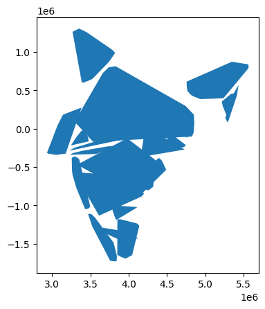

```python
# Calculamos las envolventes convexas (convex hulls) de los sistemas en el GeoDataFrame 'systems_24378'
# La propiedad convex_hull genera el menor polígono convexo que encierra cada geometría
# Esto es útil para resumir la extensión espacial de un sistema de ríos
systems_24378.convex_hull.plot()

# Graficamos las envolventes convexas
# El método plot() visualiza las geometrías de los convex hulls en un gráfico simple
```

```python
# Tenemos demasiados hulls (envolventes convexas), por lo que trabajaremos solo con dos de ellos
# Seleccionamos dos sistemas específicos usando sus índices 3 y 8 del GeoDataFrame 'systems_24378'
# Usamos .loc para acceder a las filas por índice y seleccionamos todas las columnas (indicado por ':')
systemsKeep = systems_24378.loc[(3, 8), :]

# El nuevo GeoDataFrame 'systemsKeep' contiene únicamente los dos sistemas seleccionados
# Esto permite centrarnos en un subconjunto más pequeño para análisis o visualización
```

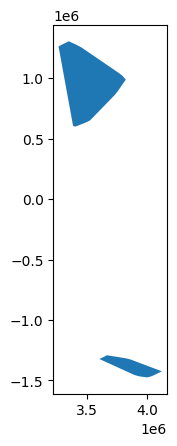

```python
# Graficamos las envolventes convexas (convex hulls) de los sistemas seleccionados en 'systemsKeep'
# La propiedad convex_hull genera el menor polígono convexo que encierra cada geometría
# El método plot() muestra estos convex hulls en un gráfico estático
systemsKeep.convex_hull.plot()
```

```python
# Creamos un GeoDataFrame para las envolventes convexas (hulls)
# Esto permitirá realizar cálculos, como una matriz de distancias, más adelante

# Convertimos las geometrías de convex hulls a un DataFrame
# 'to_frame()' crea un DataFrame con las geometrías
systems_hulls = systemsKeep.convex_hull.to_frame()

# Agregamos una columna con nombres descriptivos para los sistemas
# Esto asigna manualmente los nombres 'Cauvery' e 'Indus' a los sistemas seleccionados
systems_hulls['system'] = ['Cauvery', 'Indus']

# Renombramos la columna generada por 'to_frame' a 'geometry' para cumplir con el formato de un GeoDataFrame
systems_hulls.rename(columns={0: 'geometry'}, inplace=True)

# Convertimos el DataFrame en un GeoDataFrame configurando la geometría
# 'set_geometry' asegura que la columna 'geometry' sea reconocida como geometría espacial
systems_hulls = systems_hulls.set_geometry('geometry')

# Configuramos el sistema de referencia de coordenadas (CRS) para el GeoDataFrame
# EPSG:24378 es un sistema proyectado que utiliza metros, ideal para cálculos espaciales
systems_hulls.crs = "EPSG:24378"

# Mostramos el GeoDataFrame 'systems_hulls' actualizado
systems_hulls
```

|  | geometry | system |
| --- | --- | --- |
| 3 | POLYGON ((3991942.993 -1474484.465, 3991787.93... | Cauvery |
| 8 | POLYGON ((3405425.166 600245.226, 3395949.14 6... | Indus |

```python
# Creamos una matriz de distancias entre los sistemas (convex hulls) y los aeropuertos grandes
# El resultado será una matriz en kilómetros que muestra la distancia entre cada sistema y cada aeropuerto

distanceMatrixKM_sysHull_air = systems_hulls.set_index('system').geometry.apply(
    # Para cada geometría del sistema (convex hull), calculamos la distancia a todos los aeropuertos grandes
    lambda g: largeAirports.set_index('name').geometry.distance(g) / 1000  # Convertimos de metros a kilómetros
).sort_index(axis=0).sort_index(axis=1)  # Ordenamos los índices (sistemas y aeropuertos) alfabéticamente

# Mostramos la matriz de distancias para inspeccionar los resultados
distanceMatrixKM_sysHull_air
```

| name system | Chennai International Airport | Chhatrapati Shivaji International Airport | Cochin International Airport | Dabolim Airport | Indira Gandhi International Airport | Kempegowda International Airport | Manohar International Airport | Netaji Subhash Chandra Bose International Airport | Rajiv Gandhi International Airport | Rajkot International Airport | Thiruvananthapuram International Airport |
| --- | --- | --- | --- | --- | --- | --- | --- | --- | --- | --- | --- |
| Cauvery | 210.032142 | 823.765011 | 180.916984 | 394.778009 | 1807.705511 | 111.030554 | 430.457206 | 1624.903362 | 581.889584 | 1242.134821 | 329.216898 |
| Indus | 1945.058202 | 1179.015857 | 2203.453193 | 1589.256655 | 171.982675 | 1863.236094 | 1547.260245 | 1404.085693 | 1421.753326 | 875.402674 | 2406.862991 |

```python
# Identificamos las columnas (aeropuertos) con la distancia mínima desde cada sistema
# Utilizamos idxmin(axis="columns") para obtener el índice (nombre del aeropuerto)
# correspondiente a la distancia más corta en cada fila (sistema)
mins = distanceMatrixKM_sysHull_air.idxmin(axis="columns")

# Mostramos los resultados: cada sistema y el aeropuerto más cercano
mins
```

| system | 0 |
| --- | --- |
| Cauvery | Kempegowda International Airport |
| Indus | Indira Gandhi International Airport |

**dtype:** object

```python
# Identificamos las columnas (aeropuertos) con la distancia máxima desde cada sistema
# Utilizamos idxmax(axis="columns") para obtener el índice (nombre del aeropuerto)
# correspondiente a la distancia más grande en cada fila (sistema)
maxs = distanceMatrixKM_sysHull_air.idxmax(axis="columns")

# Mostramos los resultados: cada sistema y el aeropuerto más lejano
maxs
```

| system | 0 |
| --- | --- |
| Cauvery | Indira Gandhi International Airport |
| Indus | Thiruvananthapuram International Airport |

**dtype:** object

```python
# Ahora graficamos todo en un mapa interactivo
# Iniciamos el mapa con las geometrías de los sistemas (convex hulls)
base = systems_hulls.explore()

# Agregamos los aeropuertos más cercanos al mapa
# Filtramos los aeropuertos que están en la lista 'mins' (los más cercanos) y los graficamos en color verde
largeAirports[largeAirports.name.isin(mins)].explore(
    m=base,                         # Agregamos esta capa al mapa base
    color='green',                  # Los puntos se mostrarán en color verde
    marker_kwds=dict(radius=10)     # Configuramos el tamaño del marcador
)

# Agregamos los aeropuertos más lejanos al mapa
# Filtramos los aeropuertos que están en la lista 'maxs' (los más lejanos) y los graficamos en color rojo
largeAirports[largeAirports.name.isin(maxs)].explore(
    m=base,                         # Agregamos esta capa al mapa base
    color='red',                    # Los puntos se mostrarán en color rojo
    marker_kwds=dict(radius=10)     # Configuramos el tamaño del marcador
)

# Agregamos los aeropuertos restantes al mapa
# Seleccionamos los aeropuertos que no están en las listas 'mins' ni 'maxs' y los graficamos en color azul
largeAirports[~largeAirports.name.isin(mins) & ~largeAirports.name.isin(maxs)].explore(
    m=base,                         # Agregamos esta capa al mapa base
    color='blue',                   # Los puntos se mostrarán en color azul
    marker_kwds=dict(radius=5)      # Configuramos un tamaño de marcador más pequeño
)

# Nota: Indira Gandhi Airport aparece en verde y rojo porque es el más cercano a un sistema y el más lejano a otro
```

Make this Notebook Trusted to load map: File -> Trust Notebook

[interactive chart not shown]

**Ejercicio 4**

Selecciona un mapa de líneas y uno de puntos.

Obtén el área de influencia de las líneas y selecciona una distancia.

Conserva los puntos que están dentro del área de influencia (es posible que tengas que jugar con diferentes distancias hasta que encuentres algo interesante).

```python
# Trabajamos con todos los ríos y aeropuertos grandes para calcular la matriz de distancias
# Creamos una matriz que muestra las distancias (en kilómetros) entre cada río y cada aeropuerto

distanceMatrixKM_riv_air = indiaRivers_24378.set_index('rivname').geometry.apply(
    # Para cada geometría de río (g), calculamos la distancia a todos los aeropuertos grandes
    lambda g: largeAirports.set_index('name').geometry.distance(g) / 1000  # Convertimos las distancias de metros a kilómetros
).sort_index(axis=0).sort_index(axis=1)  # Ordenamos los índices (nombres de ríos y nombres de aeropuertos) alfabéticamente

# Mostramos la matriz de distancias para inspeccionar los resultados
distanceMatrixKM_riv_air
```

| name rivname | Chennai International Airport | Chhatrapati Shivaji International Airport | Cochin International Airport | Dabolim Airport | Indira Gandhi International Airport | Kempegowda International Airport | Manohar International Airport | Netaji Subhash Chandra Bose International Airport | Rajiv Gandhi International Airport | Rajkot International Airport | Thiruvananthapuram International Airport |
| --- | --- | --- | --- | --- | --- | --- | --- | --- | --- | --- | --- |
| Ajay | 1439.149917 | 1534.431208 | 1952.467038 | 1684.506185 | 1026.010208 | 1572.666252 | 1654.833412 | 114.312328 | 1168.141407 | 1592.404312 | 2090.216284 |
| Alaknanda | 1944.495158 | 1367.366564 | 2283.654116 | 1732.543431 | 228.829377 | 1915.615685 | 1691.321798 | 1249.089220 | 1447.826489 | 1150.026619 | 2477.490230 |
| Amba | 1004.096451 | 26.701158 | 1036.418043 | 366.105515 | 1161.637510 | 792.115318 | 325.849945 | 1658.866573 | 579.541676 | 442.243769 | 1244.816428 |
| Ambika | 1120.261576 | 186.514290 | 1237.830724 | 589.997517 | 939.850177 | 949.657654 | 548.209372 | 1563.724362 | 631.744333 | 263.189239 | 1445.934652 |
| Andi Odai | 271.704089 | 1161.671576 | 319.001303 | 781.262342 | 2007.108878 | 298.995472 | 806.182719 | 1695.831964 | 727.941459 | 1575.168489 | 385.331327 |
| ... | ... | ... | ... | ... | ... | ... | ... | ... | ... | ... | ... |
| Wainganga | 757.458598 | 747.119562 | 1156.043969 | 811.373560 | 1038.419110 | 768.610414 | 783.638473 | 976.157639 | 306.245021 | 977.781987 | 1330.870059 |
| Wainganga | 761.797515 | 743.345894 | 1159.150887 | 812.701210 | 728.180155 | 771.851702 | 784.921781 | 868.409117 | 308.711137 | 879.752189 | 1334.306085 |
| Wardha | 751.561057 | 601.745193 | 1140.652956 | 764.341153 | 763.561486 | 754.062913 | 729.792259 | 977.846637 | 287.076103 | 747.022082 | 1317.405354 |
| Yamuna | 1401.522466 | 1051.126909 | 1814.154573 | 1366.814411 | 16.853645 | 1428.310558 | 1327.822098 | 740.386469 | 958.921180 | 880.840688 | 1991.503903 |
| Zungki | 2136.508297 | 2400.052640 | 2679.614408 | 2511.379402 | 1780.150206 | 2320.433578 | 2485.829396 | 734.903952 | 1968.816335 | 2458.344499 | 2787.640083 |

110 rows × 11 columns

```python
# Seleccionamos un valor específico de la matriz de distancias:
# la distancia máxima entre el río "Ganga" y todos los aeropuertos
distanceMatrixKM_riv_air.loc['Ganga'].max()
```

```
2005.997348176404
```

```python
# Calculamos un buffer (zona de influencia) alrededor del río "Ganga"
# Usamos la distancia máxima entre el río "Ganga" y los aeropuertos, multiplicada por 10 como radio del buffer

# Obtenemos la distancia máxima entre el río "Ganga" y los aeropuertos, y la multiplicamos por 10
# Esto genera el radio del buffer en las unidades del CRS (en este caso, metros)
maxMts = distanceMatrixKM_riv_air.loc['Ganga'].max() * 10

# Creamos el buffer (un polígono) alrededor de la geometría del río "Ganga"
# Filtramos el GeoDataFrame indiaRivers_24378 para seleccionar solo el río "Ganga"
# Aplicamos el método .buffer() con el radio calculado para generar la zona de influencia
indiaRivers_24378[indiaRivers_24378.rivname == 'Ganga'].buffer(distance=maxMts)
```

|  | 0 |
| --- | --- |
| 20 | POLYGON ((3696077.44 617940.225, 3696072.804 6... |

**dtype:** geometry

```python
# Visualizamos lo que hemos creado hasta ahora: el buffer y el río "Ganga"

# Creamos el buffer alrededor del río "Ganga"
# Usamos la distancia máxima calculada previamente como radio del buffer
bufferAroundGanga = indiaRivers_24378[indiaRivers_24378.rivname == 'Ganga'].buffer(distance=maxMts)

# Exploramos el buffer visualmente en un mapa interactivo
# Asignamos el color rojo para representar el área del buffer
bufferAsBase = bufferAroundGanga.explore(color='red')

# Agregamos la geometría original del río "Ganga" al mapa interactivo
# Usamos color azul para distinguir la línea del río dentro del buffer
# Modificamos el grosor de la línea con el argumento style_kwds
indiaRivers_24378[indiaRivers_24378.rivname == 'Ganga'].explore(
    m=bufferAsBase,                  # Añadimos esta capa al mapa base que ya tiene el buffer
    color='blue',                    # Usamos color azul para el río
    style_kwds={'weight': 0.5}       # Ajustamos el grosor de la línea
)
```

Make this Notebook Trusted to load map: File -> Trust Notebook

[interactive chart not shown]

```python
# Filtramos todos los aeropuertos pequeños dentro del buffer del río "Ganga"
# Esto es útil porque los aeropuertos pequeños son más numerosos que los de otros tamaños

# Filtramos los aeropuertos que son de tipo "small_airport" del GeoDataFrame de aeropuertos
small_airports = airports[airports['kind'] == 'small_airport']

# Usamos el método clip() para seleccionar únicamente los aeropuertos pequeños
# cuyas geometrías estén dentro del buffer alrededor del río "Ganga"
airportsWithinBuffer = small_airports.clip(mask=bufferAroundGanga)

# Mostramos los aeropuertos pequeños que se encuentran dentro del buffer
airportsWithinBuffer
```

|  | name | kind | latitude_deg | longitude_deg | elevation_ft | region_name | municipality | geometry |
| --- | --- | --- | --- | --- | --- | --- | --- | --- |
| 207 | Kanpur Civil Airport (Old) | small_airport | 26.440857 | 80.365029 | 411.0 | Uttar Pradesh | Kanpur | POINT (3978964.328 314135.75) |
| 144 | IIT Kanpur Airport | small_airport | 26.520399 | 80.232904 | 400.0 | Uttar Pradesh | Kanpur | POINT (3964804.96 321404.263) |
| 264 | Benti Airstrip | small_airport | 25.672920 | 81.495920 | NaN | Uttar Pradesh | Benti | POINT (4102200.113 243020.355) |
| 267 | Andhau Airfield | small_airport | 25.615500 | 83.560640 | NaN | Uttar Pradesh | Biraich | POINT (4309663.292 265004.934) |
| 310 | Bihta Air Force Station | small_airport | 25.591240 | 84.883120 | NaN | Bihar | Patna | POINT (4442151.332 282582.057) |
| 263 | Ulao Aerodrome | small_airport | 25.427880 | 86.088190 | NaN | Bihar | Begusarai | POINT (4565365.332 284515.859) |
| 146 | Malda Airport | small_airport | 25.010180 | 88.126917 | 79.0 | West Bengal | Malda | POINT (4777162.81 275544.132) |
| 135 | Bhagalpur Airport | small_airport | 25.249535 | 87.011976 | NaN | Bihar | Bhagalpur | POINT (4660987.982 281132.681) |
| 301 | Mohammadabad Airport | small_airport | 27.316258 | 79.451555 | NaN | Uttar Pradesh | Mohammadabad | POINT (3877603.554 400713.933) |

```python
# Ahora tenemos suficiente información para visualizar todo junto en un mapa interactivo

# Visualizamos el buffer alrededor del río "Ganga" como base del mapa
# El color rojo representa el área de influencia del río "Ganga"
bufferAsBase = bufferAroundGanga.explore(color='red')

# Añadimos la geometría del río "Ganga" al mapa
# Usamos color azul para destacar el río dentro del buffer
# Ajustamos el grosor de la línea con el argumento style_kwds
indiaRivers_24378[indiaRivers_24378.rivname == 'Ganga'].explore(
    m=bufferAsBase,                  # Añadimos esta capa al mapa base que ya tiene el buffer
    color='blue',                    # Usamos color azul para la línea del río
    style_kwds={'weight': 0.5}       # Ajustamos el grosor de la línea
)

# Añadimos los aeropuertos pequeños dentro del buffer al mapa
# Usamos color negro para representar estos aeropuertos
airportsWithinBuffer.explore(
    m=bufferAsBase,                  # Añadimos esta capa al mismo mapa base
    color='black'                    # Color negro para los aeropuertos pequeños
)
```

Make this Notebook Trusted to load map: File -> Trust Notebook

[interactive chart not shown]